# FML (MIS 64060-001) - Final Exam

##### **Problem:**

When fossil fuels (coal, gas, and petroleum products) are used to make energy, they emit harmful full fumes and other greenhouse gasses into the atmosphere, triggering air quality and global warming. It can cause premature death, cardiac arrest, migraines, pulmonary problems, asthma, and a range of other disorders.

The review analyzes the information and explores numerous choices to minimize the damage and to avoid or take the necessary precaution regarding the fossil resources used for electricity generation.

##### **Technique:**

The analysis employs the K-means clustering method, that enables for the quick analysis of large data frames even while assuring convergence and the ability to warm-start the locations of centroids. Where K-means is an unsupervised machine learning approach used for clusters, we conduct on the training dataset to identify the number of clusters to participate in segmentation. I’m utilizing “ELBOW” method and “silhouette” method from the results to determine the best optimum k. The main principle underlying k-means is to identify k clusters with the least amount of within-cluster variance (or error).

##### **Appendix:**

### **K-means Cluster Analysis**

##### **Replication Requirements**

- Need to load the following packages:

```r
library(tidyverse)  # data manipulation
library(cluster)    # clustering algorithms
library(factoextra) # clustering algorithms & visualization
library(corrplot)#visualizing correlation matrices and confidence intervals
library(httr) #Configuration functions
library(readr) #Read the data
library(ISLR) #collection of data-sets
library(caret) #consistent syntax for data preparation, model building, and model evaluation
```

##### **Data Preparation**

```r
#set seed values as
set.seed(7077)

#importing Data set and converting
getwd()
```

```
[1] "/Users/avinashravipudi/Documents/Final_edits"
```

```r
FRC<-read.csv("fuel_receipts_costs_eia923.csv")

#check any NA values in the data set
sum(is.na(FRC)) # NA values in data set
```

```
[1] 2306794
```

```r
#Replace NA values with median
FRC_NO_NA<-FRC %>% replace(is.na(.), 0)
df <- FRC_NO_NA %>% mutate(across(where(is.numeric), ~replace_na(., median(., na.rm=TRUE))))

#Considering 2%  of data for analysis
df<-df %>% sample_frac(0.02)

#considering particular columns for my analysis
df<-df[, c(15:20)] # By index

#use 75%  of dataset as training set and 25%  as test set
Sample_data <- sample(c(TRUE, FALSE), nrow(df), replace=TRUE, prob=c(0.75,0.25))
# Train Data
df  <- df[Sample_data, ] # 75% Train Data

#Test Data
test   <- df[!Sample_data, ] # 25% test Dat

head(df,10)
```

|  | fuel_received_units | fuel_mmbtu_per_unit | sulfur_content_pct | ash_content_pct | mercury_content_ppm | fuel_cost_per_mmbtu |
| --- | --- | --- | --- | --- | --- | --- |
| 1 | 50961 | 1.031 | 0.00 | 0.0 | 0 | 3.650 |
| 2 | 4946 | 17.570 | 0.30 | 5.8 | 0 | 2.174 |
| 3 | 63283 | 1.030 | 0.00 | 0.0 | 0 | 2.603 |
| 4 | 12603 | 25.700 | 0.88 | 9.1 | 0 | 0.000 |
| 5 | 329859 | 1.031 | 0.00 | 0.0 | 0 | 4.050 |
| 6 | 67115 | 1.025 | 0.00 | 0.0 | 0 | 0.000 |
| 8 | 100 | 21.994 | 2.76 | 8.6 | 0 | 2.280 |
| 9 | 30296 | 19.714 | 1.00 | 25.1 | 0 | 2.450 |
| 11 | 500875 | 1.029 | 0.00 | 0.0 | 0 | 2.517 |
| 14 | 23414 | 24.790 | 1.06 | 11.9 | 0 | 2.953 |

##### **Z SCORE**

```r
set.seed(7707)
#Data frame  Z Score scaling
df_scaled <- scale(df)
summary(df_scaled)
```

```
 fuel_received_units fuel_mmbtu_per_unit sulfur_content_pct ash_content_pct   mercury_content_ppm fuel_cost_per_mmbtu
 Min.   :-0.3412     Min.   :-0.8819     Min.   :-0.51055   Min.   :-0.5517   Min.   :-0.126      Min.   :-0.05824
 1st Qu.:-0.3358     1st Qu.:-0.7798     1st Qu.:-0.51055   1st Qu.:-0.5517   1st Qu.:-0.126      1st Qu.:-0.05824
 Median :-0.3115     Median :-0.7767     Median :-0.51055   Median :-0.5517   Median :-0.126      Median :-0.03181
 Mean   : 0.0000     Mean   : 0.0000     Mean   : 0.00000   Mean   : 0.0000   Mean   : 0.000      Mean   : 0.00000
 3rd Qu.:-0.1939     3rd Qu.: 0.9284     3rd Qu.:-0.04833   3rd Qu.: 0.3578   3rd Qu.:-0.126      3rd Qu.:-0.01340
 Max.   :17.2361     Max.   : 2.1402     Max.   : 6.57361   Max.   : 9.4687   Max.   :28.482      Max.   :88.73190
```

```r
# Data Frame Range Scaling
df_range <- scale(df)
```

##### **Co-Relation**

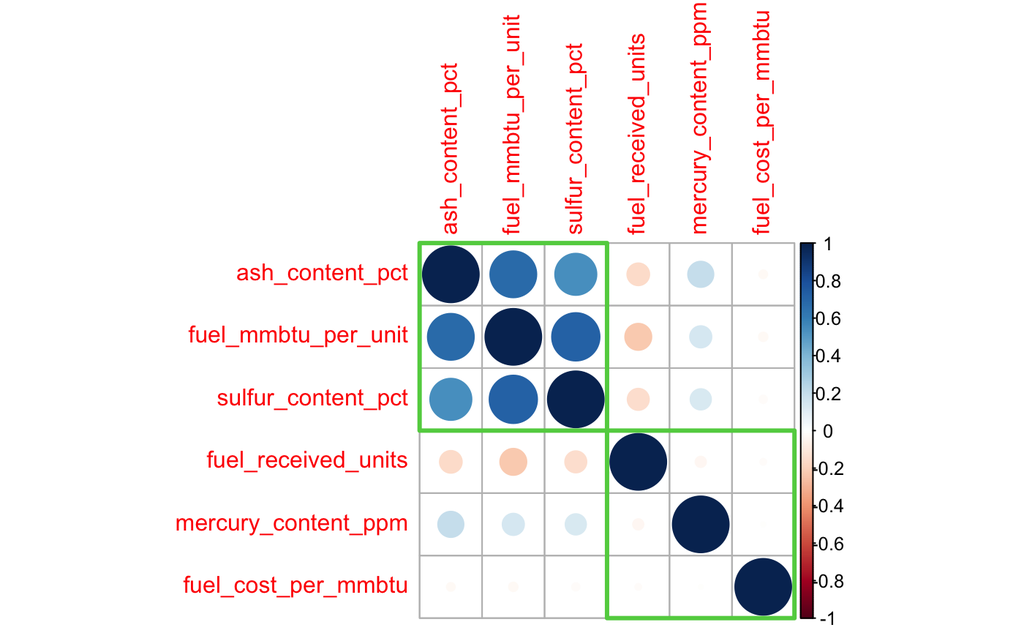

```r
#set seed value at 77077
set.seed(7707)
#finding distance of matrix
corrplot(cor(df_scaled),
         method = "circle",
         order = "hclust",         # Ordering method of the matrix
         hclust.method = "ward.D", # If order = "hclust", is the cluster method to be used
         addrect = 2,              # If order = "hclust", number of cluster rectangles
         rect.col = 3,             # Color of the rectangles
         rect.lwd = 3)             # Line width of the rectangles
```

##### **K Means**

```r
#set seed value at 77077
set.seed(7707)
k2 <- kmeans(df_scaled, centers = 2, nstart = 25)
str(k2)
```

```
List of 9
 $ cluster     : Named int [1:9206] 1 2 1 2 1 1 2 2 1 2 ...
  ..- attr(*, "names")= chr [1:9206] "1" "2" "3" "4" ...
 $ centers     : num [1:2, 1:6] 0.155 -0.278 -0.718 1.288 -0.485 ...
  ..- attr(*, "dimnames")=List of 2
  .. ..$ : chr [1:2] "1" "2"
  .. ..$ : chr [1:6] "fuel_received_units" "fuel_mmbtu_per_unit" "sulfur_content_pct" "ash_content_pct" ...
 $ totss       : num 55230
 $ withinss    : num [1:2] 18275 18868
 $ tot.withinss: num 37143
 $ betweenss   : num 18087
 $ size        : int [1:2] 5910 3296
 $ iter        : int 1
 $ ifault      : int 0
 - attr(*, "class")= chr "kmeans"
```

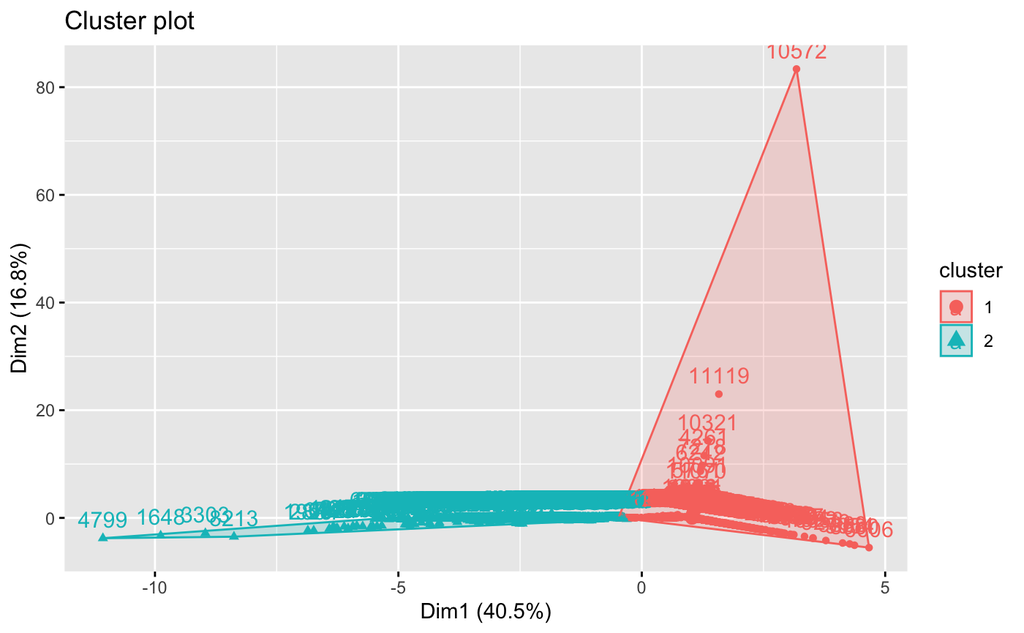

```r
#print(k2)
#visulize cluser
fviz_cluster(k2, data = df_scaled)
```

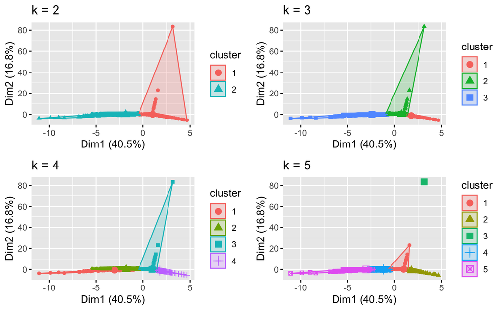

```r
#set seed value at 77077
set.seed(7707)
k3 <- kmeans(df_scaled, centers = 3, nstart = 25)
k4 <- kmeans(df_scaled, centers = 4, nstart = 25)
k5 <- kmeans(df_scaled, centers = 5, nstart = 25)

# plots to compare
p1 <- fviz_cluster(k2, geom = "point", data = df_scaled) + ggtitle("k = 2")
p2 <- fviz_cluster(k3, geom = "point",  data = df_scaled) + ggtitle("k = 3")
p3 <- fviz_cluster(k4, geom = "point",  data = df_scaled) + ggtitle("k = 4")
p4 <- fviz_cluster(k5, geom = "point",  data = df_scaled) + ggtitle("k = 5")

library(gridExtra)
grid.arrange(p1, p2, p3, p4, nrow = 2)
```

##### **ELBOW METHOOD**

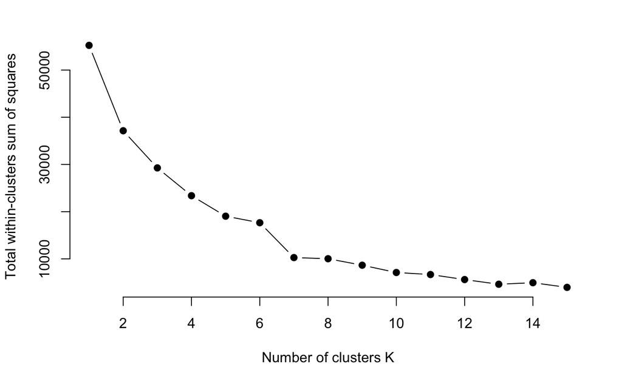

```r
set.seed(7077)

# function to compute total within-cluster sum of square
wss <- function(k) {
  kmeans(df_scaled, k, nstart = 15 )$tot.withinss
}

# Compute and plot wss for k = 1 to k = 15
k.values <- 1:15

# extract wss for 2-15 clusters
wss_values <- map_dbl(k.values, wss)

plot(k.values, wss_values,
       type="b", pch = 19, frame = FALSE,
       xlab="Number of clusters K",
       ylab="Total within-clusters sum of squares")
```

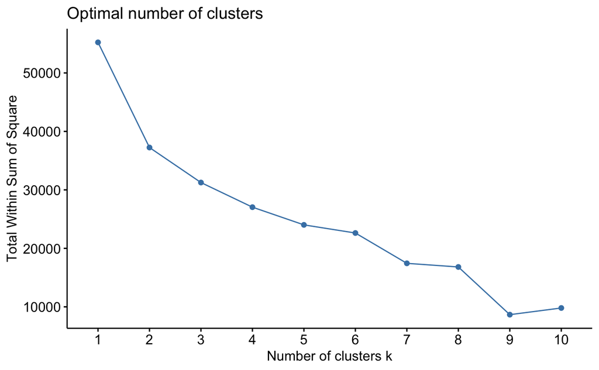

```r
#wrapped up in a single function
fviz_nbclust(df_scaled, kmeans, method = "wss")
```

##### **Silhouette Method**

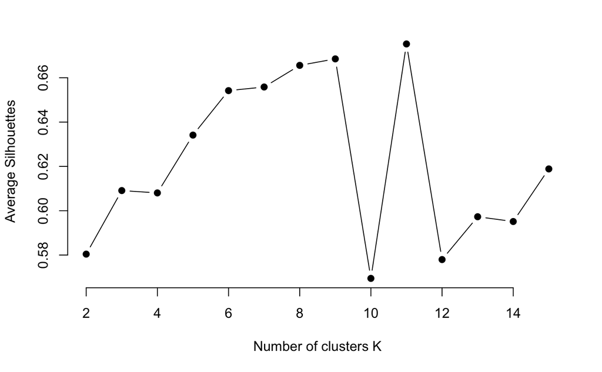

```r
set.seed(7077)
# function to compute average silhouette for k clusters
avg_sil <- function(k) {
  km.res <- kmeans(df_scaled, centers = k, nstart = 25)
  ss <- silhouette(km.res$cluster, dist(df_scaled))
  mean(ss[, 3])
}

# Compute and plot wss for k = 2 to k = 15
k.values <- 2:15

# extract avg silhouette for 2-15 clusters
avg_sil_values <- map_dbl(k.values, avg_sil)

plot(k.values, avg_sil_values,
       type = "b", pch = 19, frame = FALSE,
       xlab = "Number of clusters K",
       ylab = "Average Silhouettes")
```

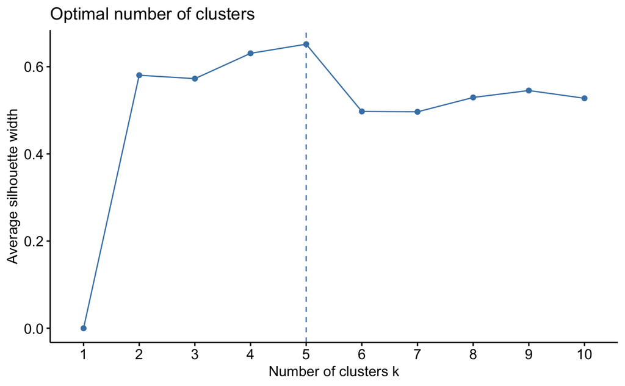

```r
#wrapped up in a single function
fviz_nbclust(df_scaled, kmeans, method = "silhouette")
```